# IODS course project

## dataset standarization

We scaled the dataset so the standard deviation for al the variables is one and then create a new crime rate variable. then we proceed to replace the old crime variable with the scaled version.

```r
boston_scaled <- scale(Boston)
summary(boston_scaled)
```

```
##       crim                 zn               indus
##  Min.   :-0.419367   Min.   :-0.48724   Min.   :-1.5563
##  1st Qu.:-0.410563   1st Qu.:-0.48724   1st Qu.:-0.8668
##  Median :-0.390280   Median :-0.48724   Median :-0.2109
##  Mean   : 0.000000   Mean   : 0.00000   Mean   : 0.0000
##  3rd Qu.: 0.007389   3rd Qu.: 0.04872   3rd Qu.: 1.0150
##  Max.   : 9.924110   Max.   : 3.80047   Max.   : 2.4202
##       chas              nox                rm               age
##  Min.   :-0.2723   Min.   :-1.4644   Min.   :-3.8764   Min.   :-2.3331
##  1st Qu.:-0.2723   1st Qu.:-0.9121   1st Qu.:-0.5681   1st Qu.:-0.8366
##  Median :-0.2723   Median :-0.1441   Median :-0.1084   Median : 0.3171
##  Mean   : 0.0000   Mean   : 0.0000   Mean   : 0.0000   Mean   : 0.0000
##  3rd Qu.:-0.2723   3rd Qu.: 0.5981   3rd Qu.: 0.4823   3rd Qu.: 0.9059
##  Max.   : 3.6648   Max.   : 2.7296   Max.   : 3.5515   Max.   : 1.1164
##       dis               rad               tax             ptratio
##  Min.   :-1.2658   Min.   :-0.9819   Min.   :-1.3127   Min.   :-2.7047
##  1st Qu.:-0.8049   1st Qu.:-0.6373   1st Qu.:-0.7668   1st Qu.:-0.4876
##  Median :-0.2790   Median :-0.5225   Median :-0.4642   Median : 0.2746
##  Mean   : 0.0000   Mean   : 0.0000   Mean   : 0.0000   Mean   : 0.0000
##  3rd Qu.: 0.6617   3rd Qu.: 1.6596   3rd Qu.: 1.5294   3rd Qu.: 0.8058
##  Max.   : 3.9566   Max.   : 1.6596   Max.   : 1.7964   Max.   : 1.6372
##      black             lstat              medv
##  Min.   :-3.9033   Min.   :-1.5296   Min.   :-1.9063
##  1st Qu.: 0.2049   1st Qu.:-0.7986   1st Qu.:-0.5989
##  Median : 0.3808   Median :-0.1811   Median :-0.1449
##  Mean   : 0.0000   Mean   : 0.0000   Mean   : 0.0000
##  3rd Qu.: 0.4332   3rd Qu.: 0.6024   3rd Qu.: 0.2683
##  Max.   : 0.4406   Max.   : 3.5453   Max.   : 2.9865
```

```r
class(boston_scaled)
```

```
## [1] "matrix"
```

```r
boston_scaled <- as.data.frame(boston_scaled)
bins <- quantile(boston_scaled$crim)
crime <- cut(boston_scaled$crim, breaks = bins, include.lowest = TRUE, label=c("low","med_low", "med_high", "high"))
table(crime)
```

```
## crime
##      low  med_low med_high     high
##      127      126      126      127
```

```r
boston_scaled <- dplyr::select(boston_scaled, -crim)
boston_scaled <- data.frame(boston_scaled, crime)
```

Then we divide the dataset randomly into train (80% of the data) and test (20% of the data) sets

```r
n <- nrow(boston_scaled)
ind <- sample(n,  size = n * 0.8)
train <- boston_scaled[ind,]
test <- boston_scaled[-ind,]
correct_classes <- test$crime
test <- dplyr::select(test, -crime)
```

Using Linear discriminant analysis with crime rate as the target variable and the other variables as predictors

```r
lda.fit <- lda(crime ~ . , data = train)
lda.fit
```

```
## Call:
## lda(crime ~ ., data = train)
##
## Prior probabilities of groups:
##       low   med_low  med_high      high
## 0.2376238 0.2475248 0.2574257 0.2574257
##
## Group means:
##                   zn      indus        chas        nox         rm
## low       0.88884791 -0.8936323 -0.10828322 -0.8427552  0.4036560
## med_low  -0.07176073 -0.3812455 -0.03610305 -0.6151837 -0.1029215
## med_high -0.39488943  0.2205328  0.21980846  0.4308019  0.1371113
## high     -0.48724019  1.0170690 -0.04518867  1.0538894 -0.3223248
##                 age        dis        rad        tax    ptratio
## low      -0.9073378  0.8573563 -0.6708280 -0.7522309 -0.4023928
## med_low  -0.3615386  0.4071046 -0.5523445 -0.5386775 -0.1351228
## med_high  0.4138404 -0.3918683 -0.3767174 -0.2577990 -0.3059035
## high      0.7996328 -0.8510533  1.6386213  1.5144083  0.7813507
##                black       lstat        medv
## low       0.37372527 -0.75621062  0.50202690
## med_low   0.35031728 -0.17816164  0.04862331
## med_high  0.08558287  0.02501974  0.20626073
## high     -0.75823092  0.86628123 -0.66148733
##
## Coefficients of linear discriminants:
##                 LD1          LD2        LD3
## zn       0.07014268  0.708572372 -0.9839679
## indus    0.01973339 -0.241100691  0.2766343
## chas    -0.07319415 -0.047860763  0.0421295
## nox      0.35964475 -0.733997701 -1.4171280
## rm      -0.06006972 -0.182989483 -0.2207048
## age      0.27199495 -0.288483724  0.1332182
## dis     -0.04507156 -0.256665004  0.2437902
## rad      2.82909079  1.197406299  0.0946017
## tax      0.18820913 -0.310331140  0.3961875
## ptratio  0.13283421 -0.041373570 -0.3911185
## black   -0.13866105  0.003189564  0.1074434
## lstat    0.24795180 -0.256973586  0.3082860
## medv     0.21616873 -0.448546194 -0.1996788
##
## Proportion of trace:
##    LD1    LD2    LD3
## 0.9442 0.0421 0.0137
```

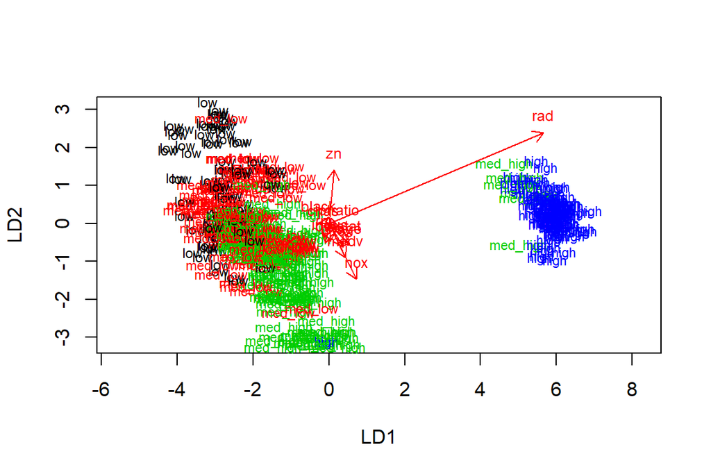

```r
lda.arrows <- function(x, myscale = 1, arrow_heads = 0.1, color = "red", tex = 0.75, choices = c(1,2)){
  heads <- coef(x)
  arrows(x0 = 0, y0 = 0,
         x1 = myscale * heads[,choices[1]],
         y1 = myscale * heads[,choices[2]], col=color, length = arrow_heads)
  text(myscale * heads[,choices], labels = row.names(heads),
       cex = tex, col=color, pos=3)
}
classes <- as.numeric(train$crime)
plot(lda.fit, dimen = 2, col=classes, pch=classes)
lda.arrows(lda.fit, myscale = 2)
```

As seen in the plot the index of accessibility to radial highways is the most important predictor. Now we predict the classes

```r
lda.pred <- predict(lda.fit, newdata = test)
table(correct = correct_classes, predicted = lda.pred$class)
```

```
##           predicted
## correct    low med_low med_high high
##   low       19       9        3    0
##   med_low    2      15        9    0
##   med_high   2       8       12    0
##   high       0       0        0   23
```

The predictions show how the high crime rate is well predicted using this variables.

## Distance calculation

```r
data("Boston")
boston_s <- scale(Boston)
boston_s <- as.data.frame(boston_s)
dist_eu <- dist(boston_s)
summary(dist_eu)
```

```
##    Min. 1st Qu.  Median    Mean 3rd Qu.    Max.
##  0.1343  3.4625  4.8241  4.9111  6.1863 14.3970
```

Now we run the k-means on the dataset with four clusters.

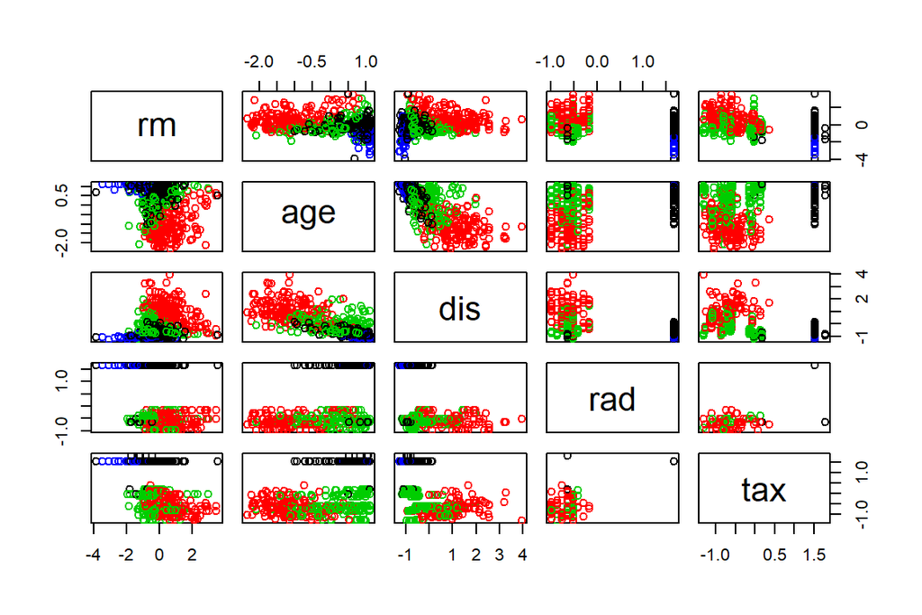

```r
km <-kmeans(boston_s, centers = 4)
pairs(boston_s[6:10], col = km$cluster)
```

Using cluster sum of squares to calculate and visualize the optimal number of clusters

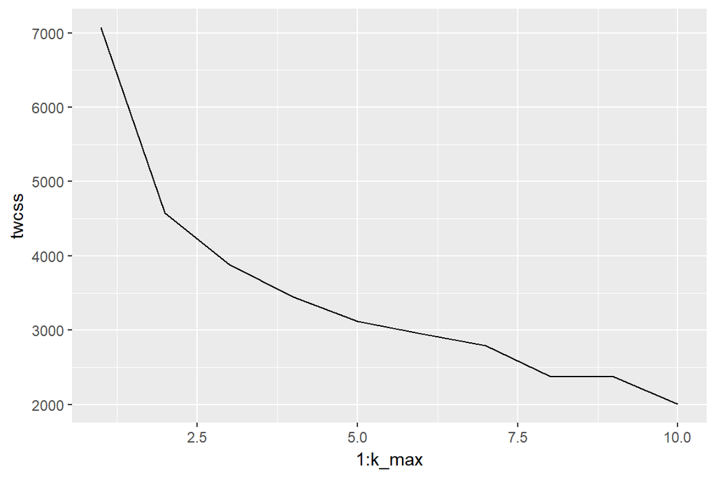

```r
library(ggplot2)
set.seed(123)
k_max <- 10
twcss <- sapply(1:k_max, function(k){kmeans(boston_s, k)$tot.withinss})
qplot(x = 1:k_max, y = twcss, geom = 'line')
```

We run the plot again using two clusters

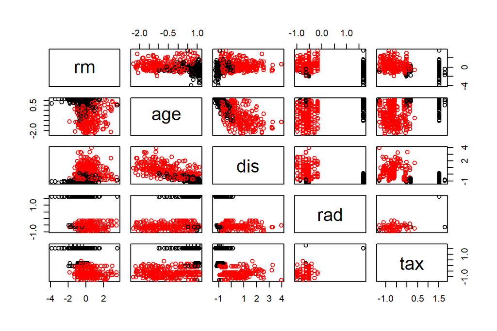

```r
library(GGally)
km <-kmeans(boston_s, centers = 2)
pairs(boston_s[6:10],col = km$cluster)
```